# Bounding box detection - Racoon data

## Data files

- images_racoon.rar: contain images of racoons
- train_labels.cv: contains coordinates for bounding box for every image

### Import the necessary libraries

```python
# IMPORT LIBRARIES AND PACKAGES
import tensorflow as tf
import csv
import numpy as np
from PIL import Image

from tensorflow.keras import Model
from tensorflow.keras.applications.mobilenet import MobileNet, preprocess_input
from tensorflow.keras.callbacks import ModelCheckpoint, EarlyStopping, ReduceLROnPlateau, Callback
from tensorflow.keras.layers import Conv2D, Reshape
from tensorflow.keras.utils import Sequence
from tensorflow.keras.backend import epsilon

import csv

import pandas as pd

from zipfile import ZipFile
```

### Change directory

```python
# Not required, as working on local anaconda
```

### Load the training data from train.csv file

```python
train_csv = pd.read_csv('train_labels.csv')
train_csv.head()
```

|  | filename | width | height | class | xmin | ymin | xmax | ymax |
| --- | --- | --- | --- | --- | --- | --- | --- | --- |
| 0 | raccoon-17.jpg | 259 | 194 | raccoon | 95 | 60 | 167 | 118 |
| 1 | raccoon-11.jpg | 660 | 432 | raccoon | 3 | 1 | 461 | 431 |
| 2 | raccoon-63.jpg | 600 | 400 | raccoon | 74 | 107 | 280 | 290 |
| 3 | raccoon-63.jpg | 600 | 400 | raccoon | 227 | 93 | 403 | 298 |
| 4 | raccoon-60.jpg | 273 | 185 | raccoon | 58 | 33 | 197 | 127 |

### Print the shape of the train dataset

```python
train_csv.shape
```

```
(173, 8)
```

### Declare a variable IMAGE_SIZE = 128 as we will be using MobileNet which will be taking Input shape as 128 * 128

```python
IMAGE_SIZE = 128
```

### With the help of csv.reader write a for loop which can load the train.csv file and store the path, width, height, x0,y0,x1,y1 in induvidual variables.

1. Create a list variable known as 'path' which has all the path for all the training images
2. Create an array 'coords' which has the resized coordinates of the bounding box for the training images

Note: All the training images should be downsampled to 128 *128 as it is the input shape of MobileNet (which we will be using for Object detection). Hence the corresponding coordinates of the bounding boxes should be changed to match the image dimension of 128* 128

```python
TRAIN_CSV = 'train_labels.csv'

IMAGE_SIZE = 128 # MobileNet takes images of size 128*128*3

with open(TRAIN_CSV, 'r') as csvfile:
    paths = []
    num_rec_csv = sum(1 for line in csvfile)
    coords = np.zeros((num_rec_csv-1, 4))  # Declare a array of zeros
    reader = csv.reader(csvfile, delimiter=',')  # Read file using appropriated delimiter
    csvfile.seek(0)
    for i, row in enumerate(reader, start=0):
        if i == 0:  # First row is
            continue
        # Read row values
        path, width, height, _, x0, y0, x1, y1 = row
        path = "./images/" + path

        # Since first row was skipped, therefore reducing index by 1
        coords[i-1, 0] = int(x0) * IMAGE_SIZE / int(width) # Normalize bounding box by image size
        coords[i-1, 1] = int(y0) * IMAGE_SIZE / int(height) # Normalize bounding box by image size
        coords[i-1, 2] = (int(x1) - int(x0)) * IMAGE_SIZE / int(width) # Normalize bounding box by image size
        coords[i-1, 3] = (int(y1) - int(y0)) * IMAGE_SIZE / int(height)
        paths.append(path)

print(len(coords))
print(len(paths))
```

```
173
173
```

### Write a for loop which can load all the training images into a variable 'batch_images' using the paths from the 'paths' variable

Note: Convert the image to RGB scale as the MobileNet accepts 3 channels as inputs

```python
# install patool for reading rar file
!pip install patool
```

```python
images_rar_path = "images_racoon.rar"

# with ZipFile(images_zip_path, 'r') as z:
#     z.extractall()

import patoolib

# patoolib.extract_archive(images_rar_path)   # Extract from .rar file
```

[output not shown]

[output not shown]

```python
batch_images = np.zeros((len(paths), IMAGE_SIZE, IMAGE_SIZE, 3), dtype=np.float32)
for i, f in enumerate(paths):
    img = Image.open(f) # Read image
    img = img.resize((IMAGE_SIZE, IMAGE_SIZE)) # Resize image
    img = img.convert('RGB')
    batch_images[i] = preprocess_input(np.array(img, dtype=np.float32))
```

```python
print(len(batch_images))
print(len(coords))
print(len(paths))

print(batch_images.shape)
```

```
173
173
173
(173, 128, 128, 3)
```

### Import MobileNet and load MobileNet into a variable named 'model' which takes input shape of 128 *128* 3. Freeze all the layers. Add convolution and reshape layers at the end to ensure the output is 4 coordinates

```python
ALPHA = 1.0 # Width hyper parameter for MobileNet (0.25, 0.5, 0.75, 1.0). Higher width means more accurate but slower

model = MobileNet(input_shape=(IMAGE_SIZE, IMAGE_SIZE, 3), include_top=False, alpha=ALPHA) # Load pre-trained mobilenet
# Do not include classification (top) layer

# to freeze layers, except the new top layer, of course, which will be added below
for layer in model.layers:
    layer.trainable = False

# Add new top layer which is a conv layer of the same size as the previous layer so that only 4 coords of BBox can be output
x = model.layers[-1].output
x = Conv2D(4, kernel_size=4, name="coords")(x)
# In the line above kernel size should be 3 for img size 96, 4 for img size 128, 5 for img size 160 etc.
x = Reshape((4,))(x) # These are the 4 predicted coordinates of one BBox

model = Model(inputs=model.input, outputs=x)
```

### Define a custom loss function IoU which calculates Intersection Over Union

```python
def loss(gt,pred):
    intersections = 0
    unions = 0
    diff_width = np.minimum(gt[:,0] + gt[:,2], pred[:,0] + pred[:,2]) - np.maximum(gt[:,0], pred[:,0])
    diff_height = np.minimum(gt[:,1] + gt[:,3], pred[:,1] + pred[:,3]) - np.maximum(gt[:,1], pred[:,1])
    intersection = diff_width * diff_height

    # Compute union
    area_gt = gt[:,2] * gt[:,3]
    area_pred = pred[:,2] * pred[:,3]
    union = area_gt + area_pred - intersection

#     Compute intersection and union over multiple boxes
    for j, _ in enumerate(union):
        if union[j] > 0 and intersection[j] > 0 and union[j] >= intersection[j]:
            intersections += intersection[j]
            unions += union[j]

    # Compute IOU. Use epsilon to prevent division by zero
    iou = np.round(intersections / (unions + epsilon()), 4)
    iou = iou.astype(np.float32)
    return iou

def IoU(y_true, y_pred):
    #iou = tf.py_func(loss, [y_true, y_pred], tf.float32)
    iou = tf.py_function(loss, [y_true, y_pred], tf.float32)
    return iou
```

```python
model.compile(optimizer='Adam', loss='mse', metrics=[IoU]) # Regression loss is MSE
```

```python
model.fit(batch_images,coords,
            epochs=100,batch_size = 32,
            verbose=1)
```

```
Train on 173 samples
```

```
<tensorflow.python.keras.callbacks.History at 0x1732db59488>
```

### Pick a test image from the given data

```python
# Pick a test image, run model, show image, and show predicted bounding box overlaid on the image
import cv2
filename = './images/raccoon-1.jpg'
unscaled = cv2.imread(filename) # Original image for display
```

### Resize the image to 128 * 128 and preprocess the image for the MobileNet model

```python
height, width, _ = unscaled.shape
image = cv2.resize(unscaled, (IMAGE_SIZE, IMAGE_SIZE)) # Rescaled image to run the network
fead_scaled = preprocess_input(np.array(image, dtype=np.float32))
```

### Predict the coordinates of the bounding box for the given test image

```python
region = model.predict(x=np.array([fead_scaled]))[0] # Predict the BBox
```

```python
# pre = cv2.rectangle(unscaled, (x0, y0), (x1, y1), (0, 255, 0), 7)
# cv2.im
```

### Plot the test image using .imshow and draw a boundary box around the image with the coordinates obtained from the model

```python
# cvimage = cv2.imread(filename)
# cvimage = cv2.rectangle(cvimage,(x0,y0),(x1,y1),(0,255,0),4)
# cv2.imshow("rt",cvimage)
```

```
92 80 226 234
77 85 471 354
```

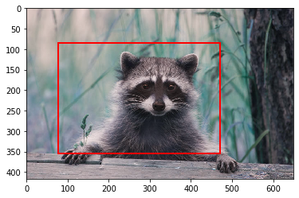

```python
print(x0, y0, x1, y1)

x0 = int(region[0] * int(width) / IMAGE_SIZE) # Scale the BBox
y0 = int(region[1] * int(height) / IMAGE_SIZE)

x1 = int((region[2]) * int(width) / IMAGE_SIZE)
y1 = int((region[3]) * int(height) / IMAGE_SIZE)

print(x0, y0, x1, y1)


import matplotlib.pyplot as plt
import matplotlib.patches as patches
from PIL import Image
import numpy as np

%matplotlib inline


# Create figure and axes
fig,ax = plt.subplots(1)

# Display the image
ax.imshow(unscaled)

# Create a Rectangle patch
rect = patches.Rectangle((x0, y0), (x1 - x0) , (y1 - y0) , linewidth=2, edgecolor='r', facecolor='none')

# Add the patch to the Axes
ax.add_patch(rect)

plt.show()
```

```python
coords.shape
```

```
(173, 4)
```

# Time Series Prediction using LSTM

### Download Data

Link: https://datamarket.com/data/set/2324/daily-minimum-temperatures-in-melbourne-australia-1981-1990#!ds=2324&display=line

#### Description

Daily minimum temperatures in Melbourne, Australia, 1981-1990

Units: Degrees Celcius

#### Steps before loading

- Rename the column name with temprature values to "Temprature"
- In the last, there is one extra row in the data, remove it by opening the file and save it again.
- There are some values in Temprature column which have a "?" before them, they will give error, remove "?" before them and save the file
- If you don't want to do these steps, just load the data file given by Great Learning.

#### Mount google drive

```python
# Not required as working on local system
```

#### Change your present working directory

```python
# Not required as working on local system
```

### Load your data file

```python
df = pd.read_csv('daily-minimum-temperatures-in-me.csv')
df.sort_index(inplace=True)
df.tail(4)
```

|  | Date | Temperature |
| --- | --- | --- |
| 3646 | 1990-12-28 | 13.6 |
| 3647 | 1990-12-29 | 13.5 |
| 3648 | 1990-12-30 | 15.7 |
| 3649 | 1990-12-31 | 13.0 |

#### Plot data

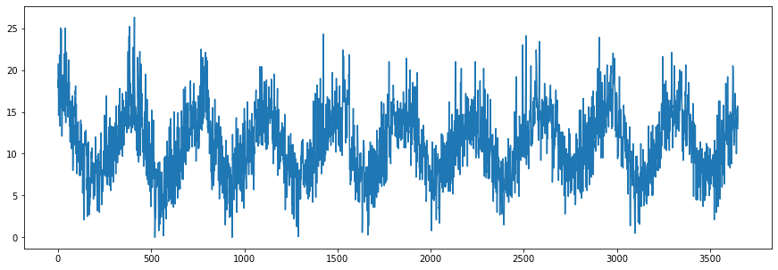

```python
plt.figure(figsize=[15,5])
plt.plot(df.Temperature)
plt.show()
```

#### Descibe your dataframe

```python
df.describe().T
```

|  | count | mean | std | min | 25% | 50% | 75% | max |
| --- | --- | --- | --- | --- | --- | --- | --- | --- |
| Temperature | 3650.0 | 11.177753 | 4.071837 | 0.0 | 8.3 | 11.0 | 14.0 | 26.3 |

#### Check for null values

```python
print(df.isnull().sum())
```

```
Date           0
Temperature    0
dtype: int64
```

#### Drop null values

```python
print(df.shape)
df.dropna(axis=1, inplace=True)
print(df.shape)
```

```
(3650, 2)
(3650, 2)
```

#### Get the representation of the distribution of data in the form of histogram

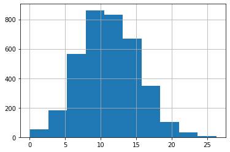

```python
df.Temperature.hist()
```

#### Check the maximum and minimum values

```python
print('Min', np.min(df))
print('Max', np.max(df))
```

```
Min Date           1981-01-01
Temperature             0
dtype: object
Max Date           1990-12-31
Temperature          26.3
dtype: object
```

### Normalize the data

```python
from sklearn.preprocessing import MinMaxScaler

scaler = MinMaxScaler(feature_range=(0, 1))
scaled = scaler.fit_transform(pd.DataFrame(df.Temperature))  # both columns are input as X
```

#### Check the maximum and minimum values of scaled data

```python
print('Min', np.min(scaled))
print('Max', np.max(scaled))
```

```
Min 0.0
Max 1.0
```

#### Look into some of the scaled values

```python
scaled[0:5]
```

```
array([[0.78707224],
       [0.68060837],
       [0.7148289 ],
       [0.55513308],
       [0.60076046]])
```

### Split data into Training and Testing

```python
#70% examples will used for training (in the begining)
train_size = int(len(scaled) * 0.70)
#30% will be used for Test
test_size = len(scaled - train_size)

#Split the data
train, test = scaled[0:train_size, :], scaled[train_size: len(scaled), :]
```

#### Print train and test size

```python
print('train: {}\ntest: {}'.format(len(train), len(test)))
```

```
train: 2555
test: 1095
```

## Create the sequential data

Map the temprature at a particular time t to the temprature at time t+n, where n is any number you define.

For example: to map tempratures of consecutive days, use t+1, i.e. loop_back = 1

#### Define your function to create dataset

```python
#window - how long the sequence will be
def create_dataset(dataset, dataset_y, window=1):

    dataX, dataY = [], []

    for i in range(len(dataset)-window):

        #a = dataset[i:(i+window), 0]  # Pick only first(index=0) column
        a = dataset[i:(i+window), ]  # Pick every column
        dataX.append(a)
        #dataY.append(dataset[i + window, 0])  # store close of the next row as the target for this row
        """
        While calculation y below, if 0 is not used then the output has shape like (1979, ).
        If 0 is used, then the output has shape like (1979, 1).
        """
        dataY.append(dataset_y[i + window, 0])  # store close of the next row as the target for this row

    return np.array(dataX), np.array(dataY)
```

#### Use function to get training and test set

```python
#Create Input and Output
window_size = 1  # Predict based on previous one entry
X_train, y_train = create_dataset(train, train, window_size)  # y is also provided by input column that make X
X_test, y_test = create_dataset(test, test, window_size) # y is also provided by input column that make X

print(X_train.shape)
print(y_train.shape)
```

```
(2554, 1, 1)
(2554,)
```

#### Transform the prepared train and test input data into the expected structure using numpy.reshape()

```python
#Make it 3 Dimensional Data - needed for LSTM
"""
Reshape into:
- number of rows
- window size(timestamp size)
- Input features
"""
X_train = np.reshape(X_train, (X_train.shape[0], 1, 1))
X_test = np.reshape(X_test, (X_test.shape[0], 1, 1))
print(X_train.shape)
print(X_test.shape)
```

```
(2554, 1, 1)
(1094, 1, 1)
```

## Define Model

### Define sequntial model, add LSTM layer and compile the model

```python
tf.keras.backend.clear_session()
model1 = tf.keras.Sequential()

model1.add(tf.keras.layers.LSTM(32, input_shape=(window_size, 1)))  # 1 is for the number of input features
model1.add(tf.keras.layers.Dense(1))
model1.compile(optimizer='adam', loss='mse')
```

### Summarize your model

```python
model1.summary()
```

```
Model: "sequential"
_________________________________________________________________
Layer (type)                 Output Shape              Param #
=================================================================
lstm (LSTM)                  (None, 32)                4352
_________________________________________________________________
dense (Dense)                (None, 1)                 33
=================================================================
Total params: 4,385
Trainable params: 4,385
Non-trainable params: 0
_________________________________________________________________
```

### Train the model

```python
"""
ERROR: UnknownError:  [_Derived_]  Fail to find the dnn implementation.
	 [[{{node CudnnRNN}}]]

SOLUTION: Close window. Stop anaconda. Start again.
"""

model1.fit(X_train, y_train, epochs=100, validation_data=(X_test, y_test), batch_size=32)
```

```
Train on 2554 samples, validate on 1094 samples
```

```
<tensorflow.python.keras.callbacks.History at 0x1732bb85988>
```

## Make Predictions and Evaluate your model

```python
#Get prediction for both Training and Test Data
trainPredict = model1.predict(X_train)
testPredict = model1.predict(X_test)

from sklearn.metrics import mean_squared_error

err = mean_squared_error(y_test, testPredict)

print(err)
```

```
0.008649897344150871
```

## Plot the results

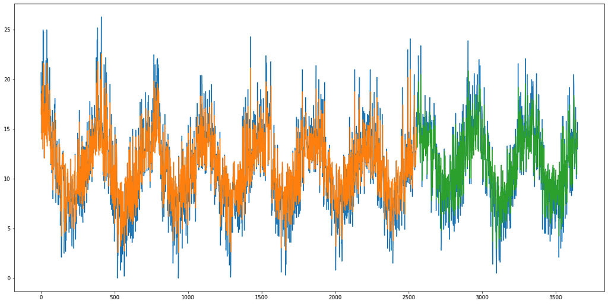

```python
# The prediction is a scaled value. Inverse transform to given regular value.
trainPredict = scaler.inverse_transform(trainPredict)
testPredict = scaler.inverse_transform(testPredict)

trainPredictPlot = np.empty_like(scaled)
trainPredictPlot[:, :] = np.nan
trainPredictPlot[window_size:len(trainPredict)+window_size, :] = trainPredict
# shift test predictions for plotting
testPredictPlot = np.empty_like(scaled)
testPredictPlot[:, :] = np.nan
testPredictPlot[len(trainPredict)+(window_size*2):len(scaled), :] = testPredict
# plot baseline and predictions
plt.figure(figsize=(20,10))
plt.plot(scaler.inverse_transform(scaled))
plt.plot(trainPredictPlot)
plt.plot(testPredictPlot)
plt.show()
```